# How do social scientists answer questions using data?

PSCI 2270 - Week 4

Georgiy Syunyaev

Department of Political Science, Vanderbilt University

September 24, 2024

## Plan for this week

1. Some math… LLN and CLT
2. Logic of causal inference

## Plan for this week

1. Some math… LLN and CLT

## Some building blocks

- **Probability:**
  - Basis for understanding uncertainty in our estimates
  - E.g. how likely that the mean of our sample is $x$ distance away from the population mean
- **Law of Large Numbers**
  - As sample size increases (e.g., roll a dice many times)
  - Average of the sample converges to the *truth*
- **Central Limit Theorem:**
  - If we collect many (large) samples
  - Result follows the normal distribution

## Random samples

- Suppose we collect $n$ observations: $X_1$ , $X_2$, … , $X_n$
  - $X_1$ is the age of the first randomly selected registered voter.
  - $X_2$ is the age of the second randomly selected registered voter, etc.
- We then summarize these $n$ observations by calculating a statistic, e.g. mean
  - All statistical procedures involve a statistic, very often sum or mean.
  - What are the properties of these sums and means?
  - Can the sample mean of age tell us anything about the population distribution of age?
- How do we know how far is this away from summary of all $N$ (or even infinite number of!) units in population?
  - **Key idea:** Can we say something about distribution of statistics across (hypothetical) re-samples?
  - **Key tool:** Increase sample size to very large asymptotics

## Stats Lingo: LLN

**Law of Large Numbers (LLN)**

Let $X_1$ , … , $X_n$ be i.i.d. random variables with mean $\mu$ and finite variance $\sigma^2$. Then, $\bar{X}_{n}$ converges to $\mu$ as $n$ gets large.

- The probability of $\bar{X}_n$ being “far away” from $\mu$ goes to $0$ as $n$ gets big
- **Intuition:** If we roll the six-sided die many times, what do you think the average of rolls will be?
- **Important result:** The distribution of sample means “collapses” to population mean if we draw *many* samples

## Stats Lingo: CLT

**Central Limit Theorem (CLT)**

Let $X_1$ , … , $X_n$ be a sample from population with mean $\mu$ and variance $\sigma^2$. Then, $\bar{X}_n$ (sample mean) will be approximately distributed $N ( \mu, \sigma^2 / n )$ as $n$ goes to infinity.

- **Intuition:** Imagine you can collect many (large) samples and for each calculate a mean, resulting means form sampling distribution that has *good* properties
- **Important result:** We now know how far away $\bar{X}_n$ can be from population mean of $X_i$ (not $\bar{X}_n$)!

## Normal Distribution

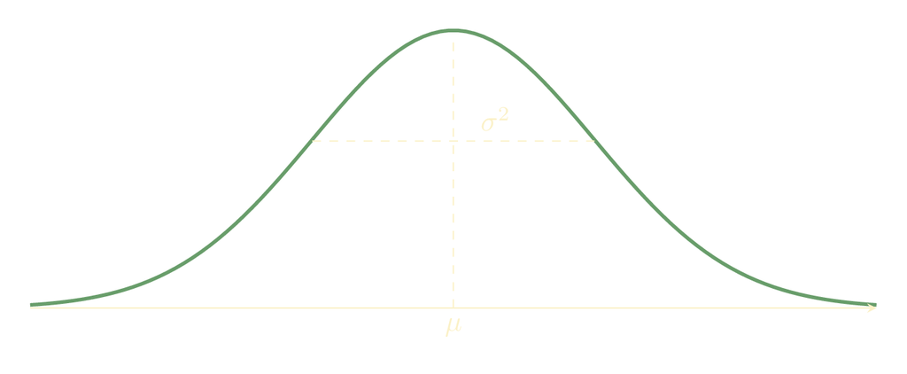

- Distribution possible value of $X$ $\rightarrow$ probability of $X$ taking this value
- The Normal distribution is one of the most ubiquitous distributions in statistics
  - Follows “bell-shaped” curve
  - Mean and variance are two key characteristics (parameters) and are given in parentheses
  - When $X$ is distributed normally, we write $X \sim N ( \mu, \sigma^2 )$
- Three key properties:
  - Unimodal: one peak at the mean
  - Symmetric around the mean
  - Everywhere positive: any real value can possibly occur

## Impications of CLT/LLN

- By CLT, sample mean is a draw from Normal distribution with mean $\mu$ and variance of $\sigma^2 / n$
- Using properties of Normal distribution sample mean will be within $2 \times \sigma^2 / n$ of the population mean 95% of the time
- We usually only have one sample, so we’ll only get one sample mean. So why do we care about LLN/CLT?
  - CLT gives us assurances our sample mean won’t be too far from population mean
  - CLT also helps us create measure of uncertainty for our estimates: standard deviation of the sampling distribution, or standard error (SE):

  $$SE = \sqrt{\frac{\sigma^2}{n}} = \frac{\sigma}{\sqrt{n}}$$

## Putting the Concepts to Work

[figure not shown]

- **Question:** *What proportion of the public approves of Biden’s job as president?*
- Latest Gallup poll:
  - September 3-15
  - 1007 adult Americans
  - Telephone interviews using RDD
  - Approve (39%), Disapprove (58%)
  - Devil in the Details
- What can we learn about Biden’s approval in the population from this one sample?

## Samples from Population

- **Our data:** simple random sample of size $n$ from some population $X_1$ , … , $X_n$
  - Each individual is independently drawn $\Rightarrow$ $i.i.d.$ random variables
  - $X_i = 1$ if $i$ approves of Biden, $X_i = 0$ otherwise
- We will use data to guess something about the population distribution of $X_i$ $\Leftarrow$ statistical inference

## Point Estimation

- Point estimation: providing a single “best guess” as to the value of some fixed, unknown quantity of interest, $\theta$ (read theta)
  - $\theta$ is a feature of the population distribution
  - Also called parameters
- Examples of quantities of interest ( estimands ):
  - $\mu = \mathbb{E} [ X_i ]$: the population mean (turnout rate in the population)
  - $\sigma^2 = \mathrm{Var}[ X_i ]$: the population variance
  - $\mu_1 - \mu_0 = \mathbb{E} [ X_i (1) ] - \mathbb{E} [ X_i (0) ]$: the population Average Treatment Effect (ATE)
- These are the things we want to learn about

## Estimators

**Estimator**

An estimator, $\hat{\theta}$, of some parameter $\theta$, is a statistic: $\hat{\theta} = h(X_1 , ... , X_n )$.

- An estimate is one particular realization of the estimator
  - Ideally we’d like to know the estimation error (bias) $\theta - \hat\theta$
  - Problem: $\theta$ is unknown
  - Solution: figure out the properties of $\theta$ using probability
- $\hat{\theta}$ is a random variable because it is a function of sequence of random draws $\Rightarrow$ CLT and LLN apply!

## Estimating Biden’s support

- Parameter $\theta$: population proportion of adults who support Biden
- There are many ($\infty$) different possible estimators:
  - $\hat{\theta} = \bar{X}_n$ : the sample proportion of respondents who support Biden
  - $\hat{\theta} = X_1$ : just use the first observation
  - $\hat{\theta} = \max( X_1 , ... , X_n )$ : pick the maximum of all observations
  - $\hat{\theta} = 0.5$ : always guess 50% support
- How good are these different estimators?
- We usually rely on mean, partly because it makes LLN and CLT apply

## Sample mean properties

$$\underbrace{\text{estimate}}_{\text{sample mean, }\bar{X}} = \underbrace{\text{estimand}}_{\text{population mean, }p} + \text{noise}$$

- **Remember:** the sample mean is a random variable
  - Different samples give different sample means
  - Noise “bumps” sample mean away from population mean; We assume away bias
  - $\bar{X}$ has a distribution across repeated samples–sampling distribution–that we know has nice properties

## Central tendency of the sample mean

- **Expectation:** average of the estimates across repeated samples
  - From LLN: $\mathbb{E}[\bar{X}] = \mathbb{E}[ X_i ] = p$
  - $\rightarrow$ noise is $0$ on average:
    $$\mathbb{E}[\bar{X} − p] = \mathbb{E}[\bar{X}] − p = 0$$
- Un*BIAS*edness: Sample proportion is on average equal to the population proportion

## Spread of the Sample Mean

- **Standard error:** how big is the noise on average?
- We can use a special rule to binary random variables to calculate standard deviation (SD):

$$\sqrt{\mathrm{Var}(\bar{X})} = \sqrt{\frac{p(1 − p)}{n}}$$

- **Problem:** we don’t know $p$!
- **Solution:** estimate the SE using sample mean

$$\sqrt{\widehat{\mathrm{Var}}(\bar{X})} = \sqrt{\frac{\bar{X}(1 − \bar{X})}{n}} \class{fragment}{= \sqrt{\frac{0.39 (1 − 0.39)}{1007}} \approx 0.0153}$$

## Confidence Intervals

- **Awesome:** Sample proportion is correct on average; standard error estimates how variable sample proportion is across (hypothetical) samples
- **Awesome-r:** Get a range of plausible values
- Confidence interval: way to construct an interval that will contain the true value in some fixed proportion of repeated samples

## Using CLT

$$\bar{X} − p = \text{noise}$$

- How can we figure out a range of plausible noise?
  - Find a range of plausible noise and add them to X
- Central Limit Theorem:

$$\bar{X} \sim N \left( \underbrace{\mathbb{E}[X_i]}_{p}, \underbrace{\frac{\mathrm{Var}(X_i)}{n}}_{\frac{p(1-p)}{n}} \right)$$

- Noise: $\bar{X} − p$ is approximately normal with mean 0 and SD equal to $\sqrt{\frac{p(1-p)}{n}}$

## Confidence interval

- First, choose a confidence level.
  - What percent of noise do you want to count as “plausible”?
  - Convention is $95\%$.
- $100 \times (1 − \alpha)$ % confidence interval: $CI = X ± z_{\alpha/2} \times SE$
  - In polling, $\pm z_{\alpha/2} × SE$ is called the margin of error

## 95% CI’s

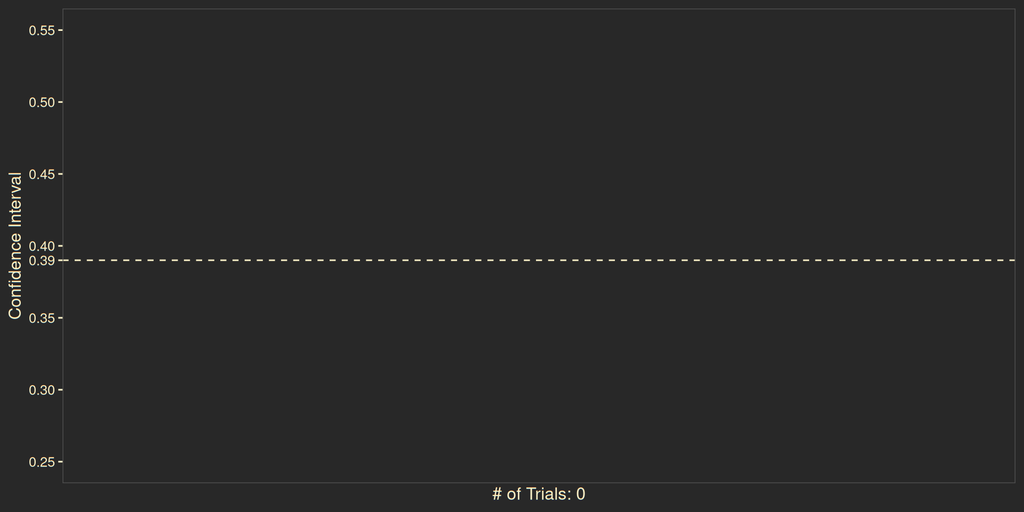

## 95% CI’s

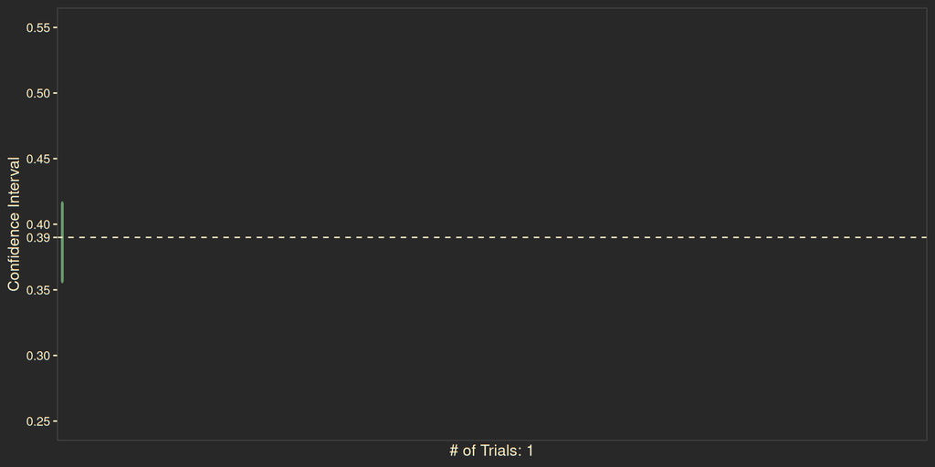

## 95% CI’s

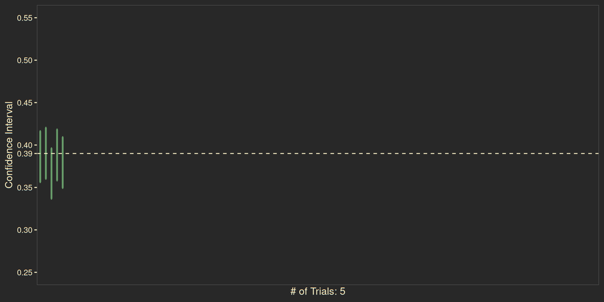

## 95% CI’s

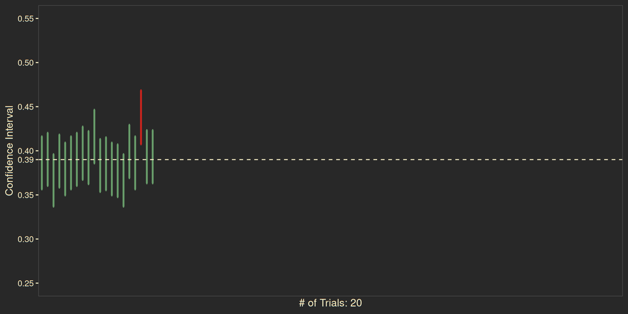

## 95% CI’s

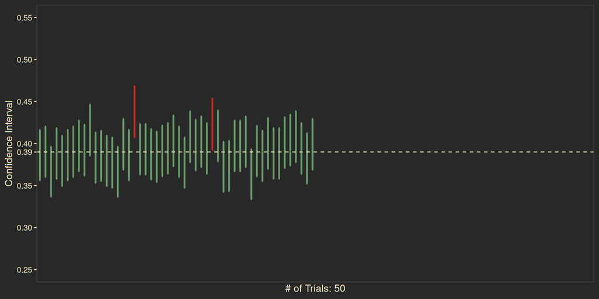

## 95% CI’s

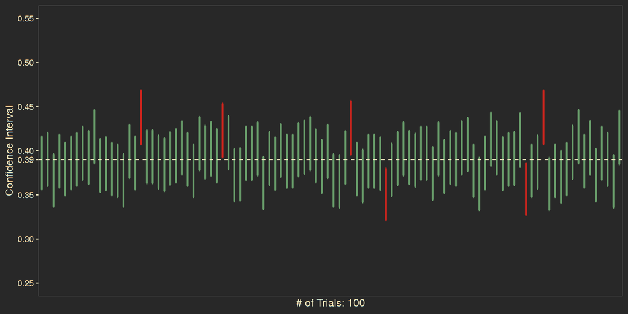

## Summary

- We know that sample mean is *unbiased* estimate of population mean $\Rightarrow$ use it as our (point) estimate of population mean
- According to CLT the sample means are normally distributed with variance of $\sigma^2 / n$ $\Rightarrow$ use sample mean and sample size to calculate *estimate* of uncertainty (sampling variance)
- Come up with confidence level (usually 95%) and use mean and variance estimates to see where the population mean is likely to be if we would to re-sample many times $\Rightarrow$ Calculate range of ~2 standard errors (square root of sampling variance) around the estimated population mean
- **95% confidence interval includes population mean in 95% of re-samples**

## Plan for this week

1. Some math… LLN and CLT
2. Logic of causal inference

## External vs Internal Validity

- So far we focused on ability to study population using just a sample $\Rightarrow$ **external validity**
- This is important if all relevant outcomes within sample are observed
  - e.g. sample mean, median, polarization, etc.
- But, for causal (“what-if”) question we cannot observe all relevant outcomes within sample $\Rightarrow$ **internal validity**
  - Why?

## Fundamental Problem of Causal Inference

- Factual vs. Counterfactual
- Does the minimum wage increase the unemployment rate?
  - Factual: Unemployment rate in US went up after the minimum wage increased
  - Counterfactual: Would it have gone up if the minimum wage increase not occurred?
- Does having a daughter affect a judge’s rulings in court?
  - Factual: A judge with a daughter gave a pro-choice ruling
  - Counterfactual: Would they have done that if they had a son instead?
- Fundamental problem of causal inference:
  - We can never observe counterfactuals $\Leftarrow$ must be inferred or assumed

## *Fundamental Problem* in Movies

[video not shown]

## Example

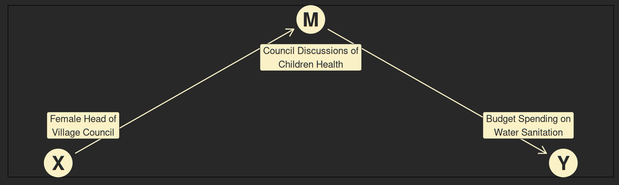

- **Question:** Does having a female as a head of a village council increase share of budget allocated to water sanitation?
- **Setting:** 8 randomly sampled villages in Indonesia (some with female and some with male head)
- **Outcome:** Share of budget each village spends on water sanitation

## Compare Two Villages

| Village | Head of Council | Budget Share |
| --- | --- | --- |
| Village 1 | Female | 15% |
| Village 2 | Male | 10% |

- Question: Did the first village have larger share spent on water sanitation *because* the head of the council was female?
- Concern: What if there are other differences between villages or the budget share leads to female council representation?

## Experimental Lingo

- **Treatment/intervention**, $T_{i}$: Who is head of council in village $i$ (was independent variable)
- **Treatment (**$T_i = 1$) group: Villages with female head of council
- **Control (**$T_i = 0$) group: Villages with male head of council
- **Outcome variable,** $Y_i$: Share of spending

| Village | $T_i$ (Head of Council) | $Y_i$ (Budget Share) |
| --- | --- | --- |
| Village 1 | 1 | 15 |
| Village 2 | 0 | 10 |

## Potential Outcomes

- What does “$T_i$ causes $Y_i$” mean?
  - Would a village with female and male head have different budget allocations?
- Imagine two states of the world: one in which you receive some treatment and another in which you do not $\Rightarrow$ **potential outcomes**
  - Treated, $Y_i (1)$: spending on water sanitation if village $i$ had a female head?
  - Untreated/Control, $Y_i (0)$: spending on water sanitation if village $i$ had a male head?

## Treatment Effect(s)

- (Individual) **Treatment effect:** $Y_i (1) − Y_i (0)$
  - $Y_i (1) − Y_i (0) = 0$: gender of village head has on spending on water sanitation
  - $Y_i (1) − Y_i (0) < 0$: female village head has negative effect on spending on water sanitation
  - $Y_i (1) − Y_i (0) > 0$: female village head has positive effect on spending on water sanitation
- **Average Treatment Effect (ATE):**

  $$\frac{1}{n} \sum_{i = 1}^{n} Y_i (1) − \frac{1}{n} \sum_{i = 1}^{n} Y_i (0) = \frac{1}{n} \sum_{i = 1}^{n} \left[ Y_i (1) − Y_i (0) \right]$$
  - Difference between average treated and untreated potential outcomes
  - Does having female head of village lead to increase in spendings on water sanitation on average?
  - *Note: You might come close to observing this treatment effect if you can observe the $Y_i (0)$ the instant before an intervention and the $Y_(1)$ the instant after, but strictly speaking, you are not observing them at the same time* $\Rightarrow$ Focus on ATE

## Back to Fundamental Problem

| Village | $T_i$ (Head of Council) | $Y_i$ (Budget Share) | $Y_i (0)$ (Budget Share if Male Head) | $Y_i (1)$ (Budget Share if Female Head) |
| --- | --- | --- | --- | --- |
| Village 1 | 1 | 15 | ??? 11 16 14 **10** | 15 |
| Village 2 | 0 | 10 | 10 | ??? 12 7 9 **15** |

- What is your best guess about treatment effect?
- Fundamental problem of causal inference:
  - We only observe one of the two potential outcomes.
  - In terms of potential outcomes: observe $Y_i = Y_i (1)$ if $T_i = 1$ or $Y_i = Y_i (0)$ if $T_i = 0$
- **To infer causal effect, we need to infer the missing counterfactuals!**
- Can we assume potential outcomes are the same?

## Matching?

[figure not shown]

- Find a similar unit! $\Rightarrow$ **matching**
  - Mill’s method of difference
- Did village spend more on water sanitation because of female council head?
  - $\rightarrow$ find a village that has male council head but very similar otherwise
- NJ increased the minimum wage. Causal effect on unemployment?
  - $\rightarrow$ find a state similar to NJ that didn’t increase minimum wage

## Imperfect matches

- The problem: imperfect matches!
- Say we match villages $i$ (treated) and $j$ (control)
- **Selection Bias:** $Y_i (1) \neq Y_j (1)$ or $Y_i (0) \neq Y_j (0)$
- Those who take *treatment* may be different from those who take *control*
- How can we correct for that?

**RANDOMIZE!** 😵‍💫

[figure not shown]

## (Social) Science Squad

[figure not shown]

## Why Does it Work?

- Fundamental problem of causal inference still prevents us from estimating individual treatment effects, **BUT…**
- Random assignment enables us to create two groups whose treated and untreated potential outcomes are the same in expectation
- The treatment group provides us with a random sample of $Y_i (1)$, and the control group provides us with a random sample of $Y_i (0)$
- The **difference-in-means** estimator compares average outcomes between two samples: treatment and control group

$$\text{Difference-in-means} = \bar{Y}_{\text{treated}} - \bar{Y}_{\text{untreated}}$$

## Core Assumptions

1. **Random assignment** of subjects to groups: Implies that receiving the treatment is statistically independent of subjects’ potential outcomes
2. **Non-interference:** A subject’s potential outcomes reflect only whether they receive the treatment themselves
   - A subject’s potential outcomes are unaffected by how the treatments happened to be allocated
3. **Excludability:** A subject’s potential outcomes respond only to the defined treatment, not other extraneous factors that may be correlated with treatment
   - Importance of defining the treatment precisely and maintaining symmetry between treatment and control groups (e.g., through blinding)

**Difference-in-means is Unbiased**

Under assumptions 1-3 *Difference-in-Means* estimator produces unbiased estimates of the *Average Treatment Tffect (ATE)*. In other words in expectation Difference-in-Means over many trials (within the same sample) we will get the Average Treatment Effect.

## Observational Methods

- All observational methods in statistics are trying to *approximate* randomization under assumptions!
- **Regression with covariates:** Block possible *known (?)* confounders
- **Matching:** Use *known (?)* covariates to match units and then compare within matched sets
- **Event study:** Use before and after treatment comparison within the same unit
- **Regression Discontinuity:** Use some naturally occurring discontinuity (e.g. tax exemption threshold, borders, etc.) to compare units around it
- **Differences-in-Differences:** Compare trends between *treated* and *untreated units* even if we know there might be differences between them
- Many other!

## Back to Example

| Village | $T_i$ (Head of Council) | $Y_i$ (Budget Share) | $Y_i (0)$ (Budget Share if Male Head) | $Y_i (1)$ (Budget Share if Female Head) |
| --- | --- | --- | --- | --- |
| Village 1 | 1 | 15 | **???** | 15 |
| Village 2 | 0 | 10 | 10 | **???** |
| Village 3 | 0 | 20 | 20 | **???** |
| Village 4 | 1 | 15 | **???** | 15 |
| Village 5 | 0 | 10 | 10 | **???** |
| Village 6 | 1 | 15 | **???** | 15 |
| Village 7 | 1 | 30 | **???** | 30 |
| Village 8 | 0 | 10 | 10 | **???** |

- What do we substitute for **???**? We need an educated guess …

## Two applications: Uncertainty

- Task: Estimate uncertainty of your difference-in-means estimate
- Steps:
  - Assume the true treatment effect is your difference in means $\Rightarrow$ reconstruct schedule of potential outcomes
  - We can use approach similar to re-sampling for sampling mean
  - Re-shuffle the treatment, for each unit take the potential outcome corresponding to new treatment see what differences-in-means you could get
- Can also be done using **parametric** approach analogous to sample mean

$$SE(\bar{Y}_{\text{treated}} - \bar{Y}_{\text{untreated}}) = \sqrt{\frac{\sigma_{\text{treated}}^2}{n_{\text{treated}}} + \frac{\sigma_{\text{untreated}}^2}{n_{\text{untreated}}}}$$

## Two applications: Hypothesis testing

- **Hypothesis testing:** There could be substantively interesting other treatment effects that we want to compare to what we observe
  - Each individual treatment effect is $0$
  - Average treatment effect is $0$
  - etc.
- We call these values of quantity of interest **hypotheses** and can see how likely are we to observe our result under those hypotheses to test them
  - Reconstruct schedule of potential outcomes assuming hypothesis is true (e.g. individual treatment effect is 0)
  - Re-shuffle the treatment, for each unit take the potential outcome corresponding to new treatment see what differences-in-means you could get
  - See how likely are you to observe value at least as extreme as yours $\Rightarrow$ **$p$-value**